# Relative stabilities of proteins inferred from a hot-spring metagenome (2011, 2013)

This vignette runs the code to make selected plots modified from the following papers:

> Dick JM, Shock EL. 2011. Calculation of the relative chemical stabilities of proteins as a function of temperature and redox chemistry in a hot spring. *PLOS One* **6**(8): e22782. doi: 10.1371/journal.pone.0022782

> Dick JM, Shock EL. 2013. A metastable equilibrium model for the relative abundances of microbial phyla in a hot spring. *PLOS One* **8**(9): e72395. doi: 10.1371/journal.pone.0072395

List of modifications:

- 2020-07-12: Plots have been modified from the originals to make more use of color.
- 2024-04-11: Oxygen was added to Figure 1.

This vignette was compiled on 2025-05-20 with **JMDplots** 1.2.22 and **[CHNOSZ](http://chnosz.net)** 2.1.0-72.

```r
library(JMDplots)
```

The current OBIGT database in CHNOSZ has updates for the methionine sidechain group from LaRowe and Dick (2012) and the glycine group and protein backbone [UPBB] from Kitadai (2014). In order to reproduce the calculations from the 2011 paper, we start by loading the older values from Dick et al. (2006).

```r
OldAAfile <- "extdata/OBIGT/OldAA.csv"
add.OBIGT(system.file(OldAAfile, package = "JMDplots"))
```

## Measured temperature, pH, and dissolved oxygen

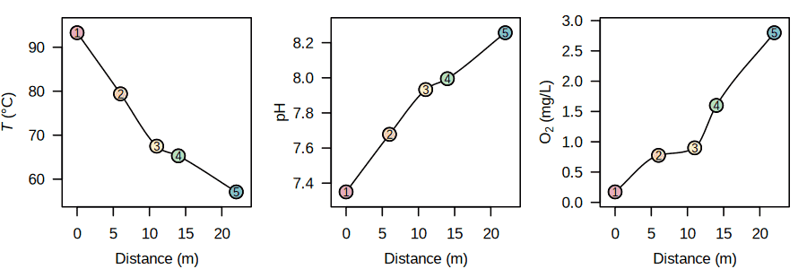

```r
bison1()
```

[Link to original figure](https://doi.org/10.1371/journal.pone.0022782.g005). The lines are spline fits that represent smooth changes in *T* and pH that are used for some plots below.

## Carbon oxidation state of proteins

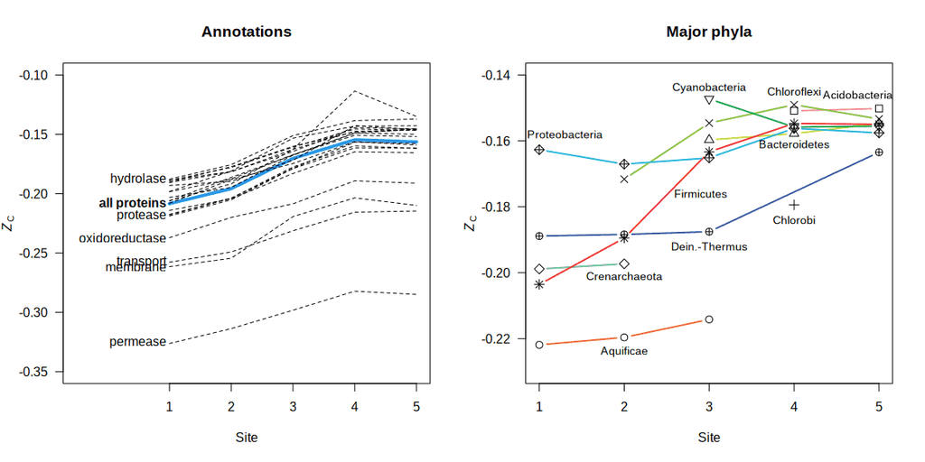

```r
bison2()
```

Links to original figures: [functional annotations](https://doi.org/10.1371/journal.pone.0022782.g004) and [major phyla](https://doi.org/10.1371/journal.pone.0072395.g001).

## Chemical affinities

```r
tab <- round(bison3(), 3)
htmltab <- capture.output(kable(tab, format = "html"))
# make selected values bold
for(i in c(15, 16, 41, 42, 43)) {
  htmltab[i] <- gsub('">', '"><b>', htmltab[i], fixed = TRUE)
  htmltab[i] <- gsub('</', '</b></', htmltab[i], fixed = TRUE)
}
structure(htmltab, format = "html", class = "knitr_kable")
```

|  | site1 | site2 | site3 | site4 | site5 |
| --- | --- | --- | --- | --- | --- |
| reaction1 | **-18.714** | **-27.892** | -35.386 | -36.823 | -42.266 |
| reaction2 | -18.839 | -27.911 | -35.319 | -36.739 | -42.121 |
| reaction3 | -19.113 | -28.051 | -35.349 | -36.749 | -42.053 |
| reaction4 | -19.263 | -28.078 | **-35.276** | **-36.657** | **-41.890** |
| reaction5 | -19.246 | -28.075 | -35.284 | -36.667 | -41.907 |

[Link to original table](https://doi.org/10.1371/journal.pone.0022782.t005). These per-residue affinities are expressed as dimensionless values, i.e. *A*/(2.303*RT*) where *A*, *R* and *T* stand for chemical affinity, gas constant, and temperature in Kelvin. The affinities are all negative, but are higher (more positive) for the reaction to form model protein 1 at sites 1 and 2 and to form model protein 4 at sites 3–5.

## Relative stabilities along a temperature and chemical gradient

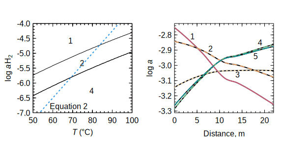

```r
bison4()
```

[Link to original figure](https://doi.org/10.1371/journal.pone.0022782.g005). The first plot is a theoretical predominance diagram for the overall model proteins from each site as a function of temperature and activity of hydrogen. The dotted line is placed so that it passes through the stability fields of the proteins at approximately the actual temperatures where they are located in the hot spring. This is Equation 2 in the 2011 paper: log *a*H<sub>2</sub> = -11 + (3/40) *T*,°C. The second plot shows the effect of changing both temperature and pH (interpolated from measured values) together with log *a*H<sub>2</sub> (from the line in the first plot) on the predicted relative abundances of the proteins in metastable equilibrium.

## Comparing old and new group additivity parameters

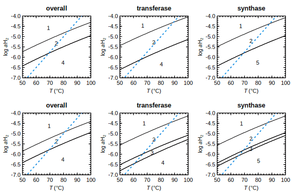

```r
bison5()
```

[Link to original figure](https://doi.org/10.1371/journal.pone.0072395.g002). The first row of plots is made using group additivity parameters from Dick et al. (2006); the second is made with updates for the methionine sidechain from LaRowe and Dick (2012) and the glycine sidechain and protein backbone group from Kitadai (2014). Note the appearance of a stability field for site 3 for some classes of proteins. The remaining figures in this vignette use the updated parameters (i.e. the current default values in OBIGT).

## Metastable equilibrium model for relative abundances

```r
equil.results <- bison6()
```

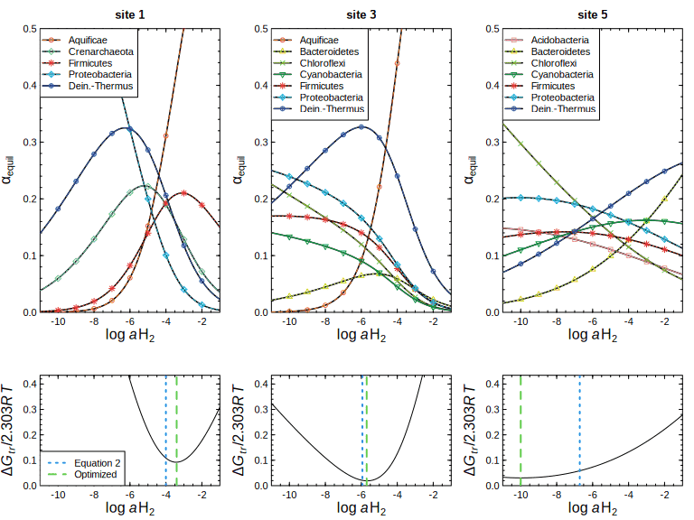

[Link to original figure](https://doi.org/10.1371/journal.pone.0072395.g003). The top row shows calculated relative abundances of the phyla based on metastable equilibrium among the model proteins as a function of log *a*H<sub>2</sub>. The bottom row shows the Gibbs energy of transformation (Δ*G<sub>tr</sub>*) between the equilibrium and actual relative abundances. Lines are drawn at values calculated with Equation 2 (see above) and at the minimum Δ*G<sub>tr</sub>*, i.e. the optimal values of log *a*H<sub>2</sub> for the model. Plots are made for only three sites, but the function returns results for all five sites, which are used below.

## Activity of hydrogen comparison

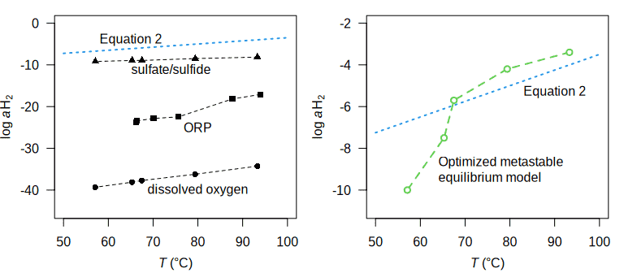

```r
bison7(equil.results)
```

## Comparison of model and observed abundances

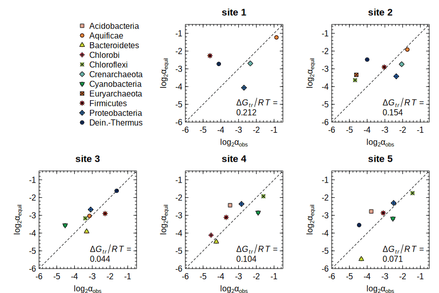

```r
bison8(equil.results)
```

[Link to original figure](https://doi.org/10.1371/journal.pone.0072395.g005).

## Document history

- 2011-08-23 Initial version.
- 2012-01-07 Use superseded properties of methionine sidechain group.
- 2014-02-01 Include results from 2013 paper and change VignetteEngine to knitr.
- 2020-07-12 Move from CHNOSZ to JMDplots; convert document from LaTeX (Rnw) to R Markdown (Rmd) and add colors.

## References

Dick JM, LaRowe DE, Helgeson HC. 2006. Temperature, pressure, and electrochemical constraints on protein speciation: Group additivity calculation of the standard molal thermodynamic properties of ionized unfolded proteins. *Biogeosciences* **3**(3): 311–336. doi: 10.5194/bg-3-311-2006

Kitadai N. 2014. Thermodynamic prediction of glycine polymerization as a function of temperature and pH consistent with experimentally obtained results. *Journal of Molecular Evolution* **78**(3-4): 171–187. doi: 10.1007/s00239-014-9616-1

LaRowe DE, Dick JM. 2012. Calculation of the standard molal thermodynamic properties of crystalline peptides. *Geochimica et Cosmochimica Acta* **80**: 70–91. doi: 10.1016/j.gca.2011.11.041